# Session 1 — Categorical Outcomes: Nominal or Ordered?

Choosing the model family · cumulative proportions · why not linear · sparse categories · Lab 1

Community Medicine Workshop

## Where we are

- Regression workshop: continuous (linear) and **binary** (logistic) outcomes
- Today: outcomes with **three or more categories**: anaemia severity, place of delivery, BP stage, disease stage
- By the end you can:
  - say whether an outcome is **nominal** or **ordered**, and why it matters
  - read **cumulative proportions**
  - explain why **linear regression** and **dichotomising** are poor choices
  - spot **sparse categories**

## Our data: a maternal health survey

- **1,500 women** with a birth in the last 3 years (synthetic, built like an NFHS-type survey)
- **Anaemia** in four **ordered** levels: None < Mild < Moderate < Severe
- **Place of delivery** in four **unordered** levels: Home, PHC, Public hospital, Private hospital
- Predictors: wealth quintile, education, residence, tribal group, antenatal visits, BMI, parity, age

```r
mat |> select(id, age, education, wealth, tribal, anc_visits, anaemia, delivery) |> head(6)
```

```
# A tibble: 6 × 8
  id      age education wealth tribal anc_visits anaemia  delivery
  <chr> <dbl> <fct>      <dbl> <fct>       <dbl> <ord>    <fct>
1 W0001    23 None           2 No              2 Moderate Public hospital
2 W0002    28 Secondary      4 No              4 None     Private hospital
3 W0003    27 Secondary      2 No              3 Mild     Public hospital
4 W0004    25 Secondary      3 Yes             7 None     Public hospital
5 W0005    30 Primary        2 Yes             3 Severe   Home
6 W0006    17 None           3 No              5 None     Public hospital
```

# Topic 1 — Which type of outcome?

## Nominal or ordered?

| Outcome | Type | Model family |
| --- | --- | --- |
| Hypertension yes/no | binary | logistic |
| **Anaemia: none, mild, moderate, severe** | **ordered** | **ordinal logistic** (proportional odds) |
| **Place of delivery** | **nominal** | **multinomial logistic** |
| Cases per month | count | Poisson / negative binomial |
| Time to death | time-to-event | Cox |

Ask: **does the order of the categories mean something?** Mild anaemia is *between* none and moderate, so anaemia is ordered. “PHC” is not between “Home” and “Public hospital” in any statistical sense, so delivery place is nominal.

## Cumulative proportions

```r
round(100 * prop.table(table(mat$anaemia)), 1)
```

```
    None     Mild Moderate   Severe
    54.4     26.5     12.2      6.9
```

```r
round(100 * cumsum(prop.table(table(mat$anaemia))), 1)
```

```
    None     Mild Moderate   Severe
    54.4     80.9     93.1    100.0
```

- The second line is **P(Y ≤ k)**: **81%** of women have *mild anaemia or better*
- The proportional-odds model (Session 2) models the **log odds of these cumulative probabilities**
- Nominal outcomes have no cumulative scale: each category is compared with a **reference**

# Topic 2 — Describing

## Anaemia by wealth

```r
round(100 * prop.table(table(mat$wealth, mat$anaemia), 1), 1)
```

```
    None Mild Moderate Severe
  1 29.6 32.7     20.8   16.9
  2 41.3 36.9     14.2    7.7
  3 59.3 23.7     11.4    5.7
  4 69.1 20.8      7.3    2.8
  5 78.2 14.5      6.7    0.6
```

```r
ggplot(mat, aes(factor(wealth), fill = anaemia)) + geom_bar(position = "fill") + scale_fill_brewer(palette = "OrRd", direction = -1) +
  labs(x = "Wealth quintile (1 = poorest)", y = "Proportion", fill = NULL)
```

The share with **no anaemia** rises from about 30% to 78%, and **severe** anaemia almost vanishes in the richest quintile. A **100% stacked bar** is the standard picture for an ordered outcome.

## Anaemia by wealth

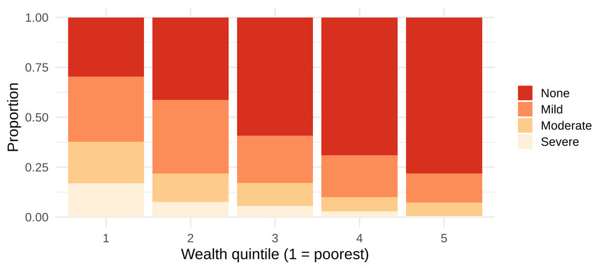

# Topic 3 — What not to do

## Treating categories as numbers

```r
coef(lm(as.numeric(anaemia) ~ wealth, data = mat))["wealth"]
```

```
    wealth
-0.2395462
```

- **Equal spacing** assumed: None to Mild is treated like Moderate to Severe
- “-0.24 categories per quintile” is **not interpretable** and can be misleading at the extremes

## Dichotomising

Collapsing to “any anaemia vs none” **throws away** the difference between mild and severe, loses **power**, and depends on **where you cut**. Use it for a simple summary, not as the analysis when the ordering is available.

## Checklist before modelling

1. **Nominal or ordered?** (order meaningful?)
2. **Counts per category**: the smallest has about 103 women here; very small categories (a few per cent or fewer than about 10 per predictor) make estimates unstable: **merge** neighbouring categories if it makes clinical sense
3. **Reference category** (nominal): choose one that is **large and meaningful** (Home)
4. Plan the **assumption check** (proportional odds)

## 🔧 Switch to R — Lab 1

**File:** `ordinal-workshop/labs/lab1_outcomes.R`

- levels, percentages and **cumulative** percentages
- 100% stacked bars by wealth
- the wrong model (linear on 1-4) and sparse-category check

**Time:** 30 minutes · answer the Q questions in the comments

## Self-check quiz (1/5)

Which outcome is ordered, and so suited to an ordinal model?

- Place of delivery: home, PHC, or a hospital
- Blood group: A, B, AB or O in the patient
- Anaemia graded none, mild, moderate or severe
- Religion recorded in the survey of households

## Self-check quiz (2/5)

The cumulative percentages for anaemia are 54, 81, 93 and 100. What does 81 mean?

- 81% of women have mild anaemia
- 81% of women have no or mild anaemia
- 81% of women have at least mild anaemia
- The odds of mild anaemia are 81

## Self-check quiz (3/5)

A linear regression of anaemia coded 1 to 4 on wealth is a poor choice because it…

- It cannot produce a coefficient for wealth from the data supplied
- It needs a much smaller number of women than the other models do
- It assumes equal gaps between the categories in severity
- It always gives a larger p-value for wealth than ordinal models do

## Self-check quiz (4/5)

What is the main cost of dichotomising an ordered outcome into ‘any anaemia’ vs ‘none’?

- It makes the outcome nominal and so impossible to model at all
- It requires the outcome data to be normally distributed in each group
- It changes the direction of the effect in the very large majority of data sets
- It discards the mild-severe difference and loses power

## Self-check quiz (5/5)

What should you check about the categories of an outcome before fitting a model?

- That no category is so small that estimates become unstable
- That the categories are listed in alphabetical order by name
- That every category has exactly the same number of women in it
- That the outcome is stored in the data file as a number

## Score and take-home

**Your score:**

- **Ordered or nominal?** decides the model family
- Ordered: **cumulative proportions**, 100% stacked bars
- Do not code categories as 1-4 in **linear regression**; avoid needless **dichotomising**
- Check **sparse categories** and choose a sensible **reference** (nominal)

**Next:** Session 2: ordinal logistic regression